# FinalProject7.Rmd

Dana Thacker, Nikole Slinger, Andrew Fahmy, Julia Lundstrum, Zack Larson

4/19/2021

1 - Nikole 2 - Julia 3 - Dana 4 - Zack 5 - Zack 6 - Nikole 7 - Dana 8 - Andrew

```r
library(ggplot2)
library(tidyverse)
library(readxl)
library(ggthemes)
library(mapproj)

raw_data <- readxl::read_xlsx("2021VaccineCovidData.xlsx", sheet='raw_data')
VAERSdata <- readxl::read_xlsx("2021VaccineCovidData.xlsx", sheet='2021VAERSDATA')
VAERSsymptoms <- readxl::read_xlsx("2021VaccineCovidData.xlsx", sheet='2021VAERSSymptoms')
VAERSVax <- readxl::read_xlsx("2021VaccineCovidData.xlsx", sheet='2021VAERSVax')
cdcdoses <- readxl::read_xlsx("2021VaccineCovidData.xlsx", sheet='2021AllVaccines')
state <- map_data("state")
abbrev <- read.csv("csvData.csv", stringsAsFactors = FALSE)
```

**1. What’s the most common symptom to experience for each manufacturer?**

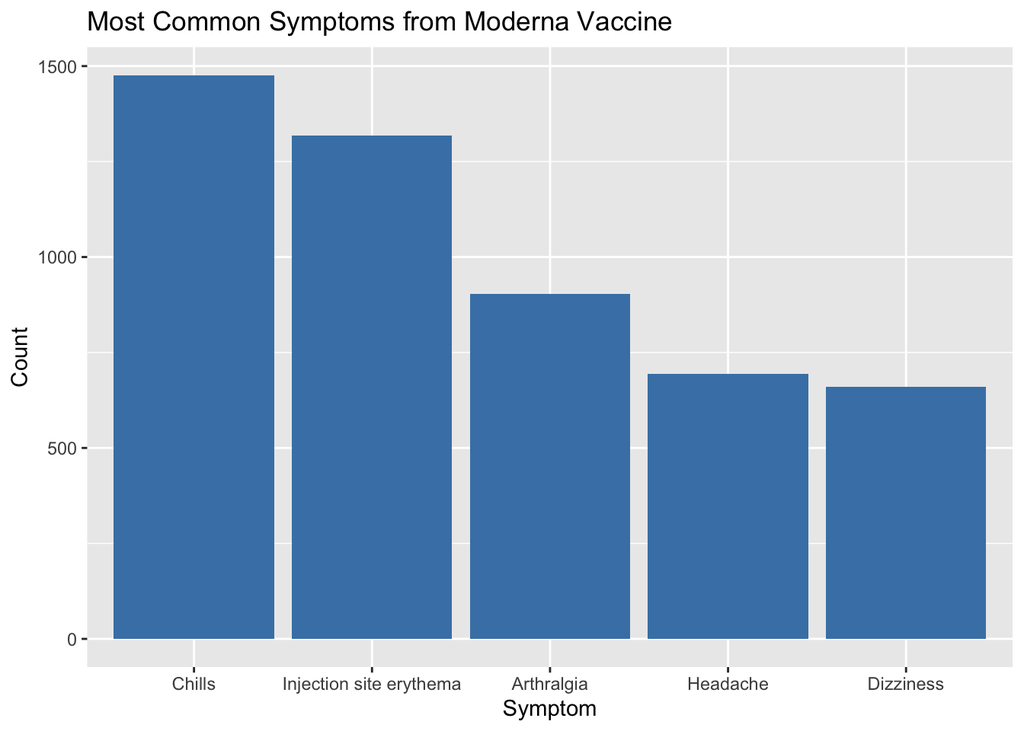

```r
# joining vax and symptom data, only need id, vaccine manu, and symptoms
symptoms <- VAERSVax %>% full_join(VAERSsymptoms, by = 'VAERS_ID') %>%
  filter(VAX_TYPE == 'COVID19') %>%
  select(VAERS_ID, VAX_MANU, SYMPTOM1, SYMPTOM2, SYMPTOM3, SYMPTOM4, SYMPTOM5)

moderna <- symptoms %>%
  filter(VAX_MANU == 'MODERNA')
moderna <- as.data.frame(sort(table(moderna$SYMPTOM1), decreasing = TRUE) [1:5])

pfizer <- symptoms %>%
  filter(VAX_MANU == 'PFIZER\\BIONTECH')
pfizer <- as.data.frame(sort(table(pfizer$SYMPTOM1), decreasing = TRUE) [1:5])

janssen <- symptoms %>%
  filter(VAX_MANU == 'JANSSEN')
janssen <- as.data.frame(sort(table(janssen$SYMPTOM1), decreasing = TRUE) [1:5])

# moderna table
ggplot(moderna, aes(x = Var1, weight = Freq)) + geom_bar(fill = 'steelblue') +
  ggtitle('Most Common Symptoms from Moderna Vaccine') +
  xlab('Symptom') + ylab('Count')
```

```r
moderna
```

```
##                      Var1 Freq
## 1                  Chills 1476
## 2 Injection site erythema 1319
## 3              Arthralgia  904
## 4                Headache  694
## 5               Dizziness  661
```

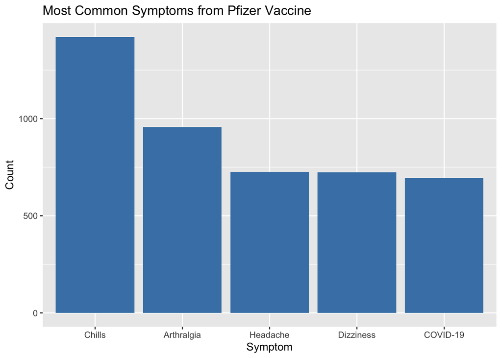

```r
# pfizer table
ggplot(pfizer, aes(x = Var1, weight = Freq)) + geom_bar(fill = 'steelblue') +
  ggtitle('Most Common Symptoms from Pfizer Vaccine') +
  xlab('Symptom') + ylab('Count')
```

```r
pfizer
```

```
##         Var1 Freq
## 1     Chills 1421
## 2 Arthralgia  957
## 3   Headache  726
## 4  Dizziness  724
## 5   COVID-19  695
```

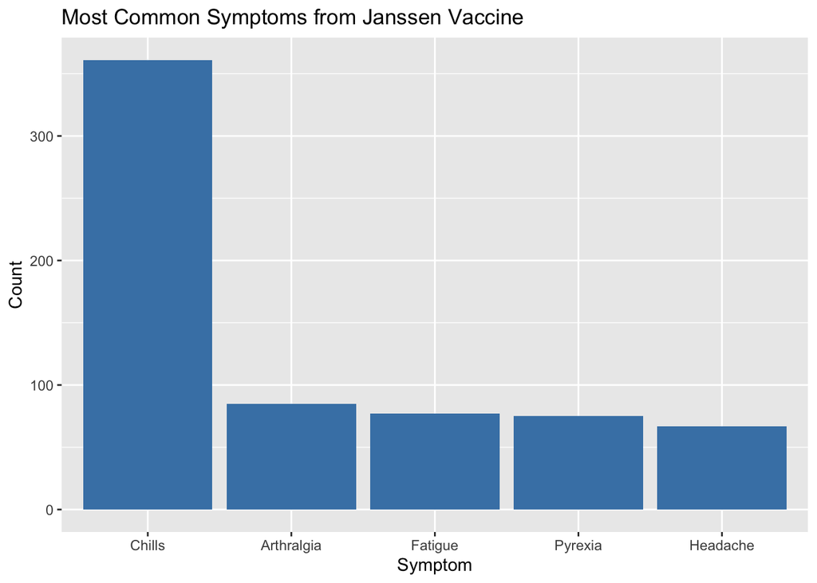

```r
# janssen table
ggplot(janssen, aes(x = Var1, weight = Freq)) + geom_bar(fill = 'steelblue') +
  ggtitle('Most Common Symptoms from Janssen Vaccine') +
  xlab('Symptom') + ylab('Count')
```

```r
janssen
```

```
##         Var1 Freq
## 1     Chills  361
## 2 Arthralgia   85
## 3    Fatigue   77
## 4    Pyrexia   75
## 5   Headache   67
```

**2. Compare Covid case cases per state in contrast to the number of vaccines administered by state**

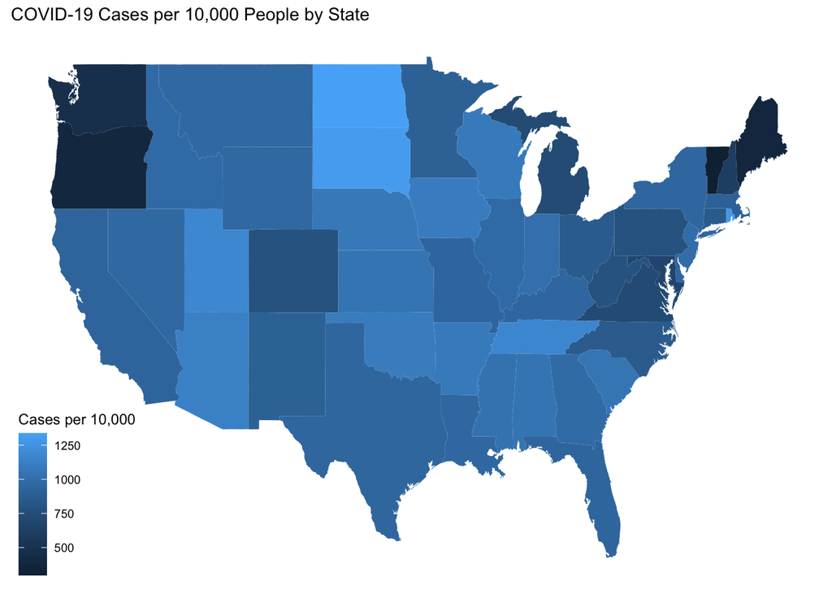

```r
cases <- raw_data %>%
  inner_join(cdcdoses, by = c("Location" = "State")) %>%
  mutate("Cases per 10,000" = `Number of COVID-19 Cases`/`Population`*10000) %>%
  mutate("Fully Vaccinated per 10,000" = `Fully Vaccinated in March`/`Population`*10000)
casesmap <- cases %>%
  mutate("State Name" = tolower(`Location`)) %>%
  right_join(state, by = c("State Name" = "region"))
ggplot(casesmap, aes(x=long, y = lat, fill = `Cases per 10,000`)) + geom_polygon(aes(group=group)) + theme_map() + ggtitle("COVID-19 Cases per 10,000 People by State")
```

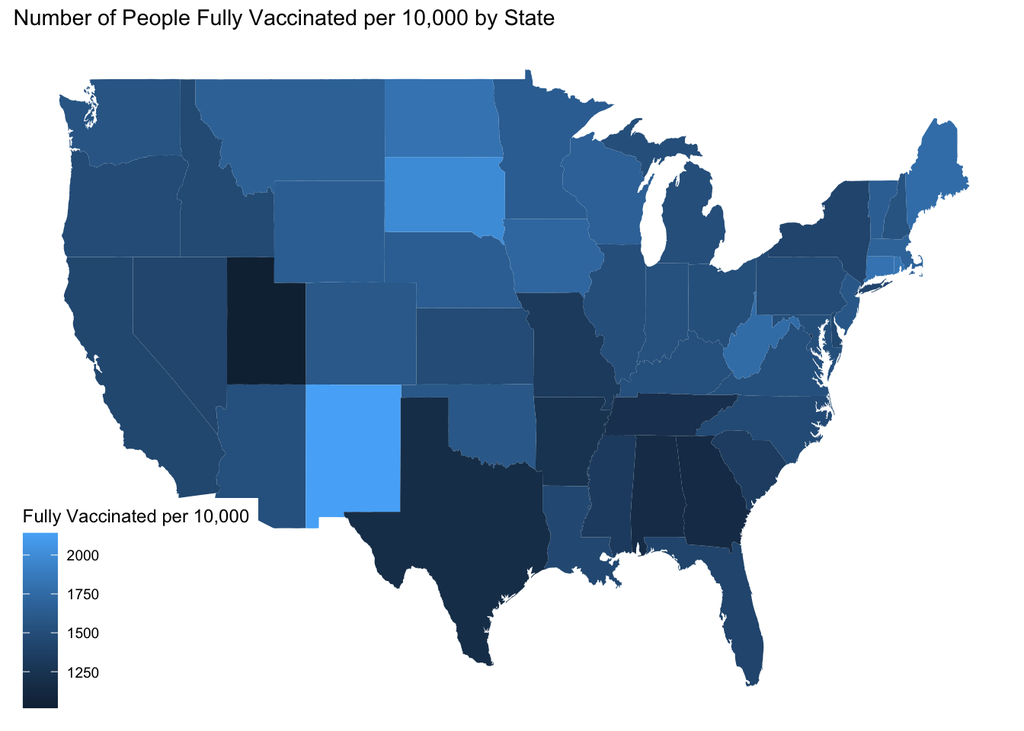

```r
ggplot(casesmap, aes(x=long, y = lat, fill = `Fully Vaccinated per 10,000`)) + geom_polygon(aes(group=group)) + theme_map() + ggtitle("Number of People Fully Vaccinated per 10,000 by State")
```

**3. Compare a patient’s medical history with their symptoms from the vaccine they received.**

```r
#Join VAERSsymptoms and VAERSdata, only need ID, all 5 symptoms, and patient history
#Then cleaning the history column to create uniformity
medHist <- VAERSsymptoms %>% full_join(VAERSdata) %>%
  select(VAERS_ID, SYMPTOM1, SYMPTOM2, SYMPTOM3, SYMPTOM4, SYMPTOM5, HISTORY) %>%
  separate(HISTORY, c('history1', 'history2', 'history3', 'history4', 'history5', 'history6', 'history7', 'history8',
                      'history9', 'history10'), sep = ', ') %>%
  mutate(history1 = tolower(history1),
         history2 = tolower(history2),
         history3 = tolower(history3),
         history4 = tolower(history4),
         history5 = tolower(history5),
         history6 = tolower(history6),
         history7 = tolower(history7),
         history8 = tolower(history8),
         history9 = tolower(history9),
         history10 = tolower(history10))
#Summarising medical history to find how often each history diagnosis appears in the dataset
medHist2 <- medHist %>%
  pivot_longer(history1:history10, names_to='histName', values_to='conditionHist') %>%
  group_by(conditionHist) %>%
  summarise(count = n())

#Creating a negation of the %in% to use in analysis
`%notin%` <- Negate(`%in%`)

#Finding the top 10, not including 5 null or 'none', medical history conditions
topHist <- top_n(medHist2, 18) %>%
  filter(conditionHist %notin% c('none',
  'comments: list of non-encoded patient relevant history: patient other relevant history 1: none', 'n/a', 'no',
  'unknown', 'medical history/concurrent conditions: no adverse event (no reported medical history)'))
topHist <- na.omit(topHist)

topHist <- topHist %>%
  mutate(conditionHist = if_else(conditionHist == 'htn', 'hypertension', conditionHist))

topHist[8,2] <- topHist[8,2] + topHist[10,2]

topHist <- topHist[-10, ]

#Filtering the medical history dataset such that I only have the top 10 medical conditions and the covid vaccination symptoms of those conditions
medHist3 <- medHist %>%
  filter(history1 %in% c('anxiety', 'asthma', 'copd', 'depression', 'diabetes', 'gerd', 'high blood pressure',
                         'hypertension', 'htn', 'hyperlipidemia', 'hypothyroidism')) %>%
  select(-history2, -history3, -history4, -history5, -history6, -history7, -history8, -history9, -history10) %>%
  rename('MedHist' = 'history1')

medHist3 <- medHist3 %>%
  mutate(MedHist = if_else(MedHist == 'htn', 'hypertension', MedHist))

#Learning about what the top symptoms are for each medical history
symptom1 <- medHist3 %>%
  group_by(MedHist, SYMPTOM1) %>%
  summarise(symptomCount = n())
symptom1 <- na.omit(symptom1)

symptom2 <- medHist3 %>%
  group_by(MedHist, SYMPTOM2) %>%
  summarise(symptomCount = n())
symptom2 <- na.omit(symptom2)

symptom3 <- medHist3 %>%
  group_by(MedHist, SYMPTOM3) %>%
  summarise(symptomCount = n())
symptom3 <- na.omit(symptom3)

symptom4 <- medHist3 %>%
  group_by(MedHist, SYMPTOM4) %>%
  summarise(symptomCount = n())
symptom4 <- na.omit(symptom4)

symptom5 <- medHist3 %>%
  group_by(MedHist, SYMPTOM5) %>%
  summarise(symptomCount = n())
symptom5 <- na.omit(symptom5)

#Selecting only the top symptom for each medical history condition for each symptom dataset
symptom1 <- top_n(symptom1, 1)
symptom2 <- top_n(symptom2, 1)
symptom3 <- top_n(symptom3, 1)
symptom4 <- top_n(symptom4, 1)
symptom5 <- top_n(symptom5, 1)
#Joining datasets to create only one symptom dataset with the top symptoms from each symptom 1-5
allSympt <- symptom1 %>% full_join(symptom2)
allSympt <- allSympt %>% full_join(symptom3)
allSympt <- allSympt %>% full_join(symptom4)
allSympt <- allSympt %>% full_join(symptom5)
#Selecting only the top symptoms when comparing symptoms 1-5
topAllSympt <- top_n(allSympt, 1, symptomCount)
head(topAllSympt, 10)
```

```
## # A tibble: 10 x 7
## # Groups:   MedHist [10]
##    MedHist       SYMPTOM1       symptomCount SYMPTOM2 SYMPTOM3 SYMPTOM4 SYMPTOM5
##    <chr>         <chr>                 <int> <chr>    <chr>    <chr>    <chr>
##  1 anxiety       Chills                   14 <NA>     <NA>     <NA>     <NA>
##  2 asthma        Chills                   98 <NA>     <NA>     <NA>     <NA>
##  3 copd          Death                    17 <NA>     <NA>     <NA>     <NA>
##  4 diabetes      Chills                   22 <NA>     <NA>     <NA>     <NA>
##  5 gerd          Chills                   14 <NA>     <NA>     <NA>     <NA>
##  6 high blood p… Chills                   41 <NA>     <NA>     <NA>     <NA>
##  7 hyperlipidem… Injection sit…            6 <NA>     <NA>     <NA>     <NA>
##  8 hypertension  Chills                   72 <NA>     <NA>     <NA>     <NA>
##  9 hypothyroidi… Chills                   28 <NA>     <NA>     <NA>     <NA>
## 10 depression    <NA>                     12 Headache <NA>     <NA>     Pyrexia
```

**4. Which states have the highest and lowest number of Covid cases and fatality rate?**

```r
raw_data2 <- raw_data
names(raw_data2)<-str_replace_all(names(raw_data2), c(" " = "."))##Column names were not ideal with numbers,commas,dashes
names(raw_data2)<-str_replace_all(names(raw_data2), c("," = "_"))
names(raw_data2)<-str_replace_all(names(raw_data2), c("-19" = ""))
highestCovidCasesStates <- raw_data2
highestCovidCasesStates$COVID.Cases.per.1_000_000.Population <- as.numeric(highestCovidCasesStates$COVID.Cases.per.1_000_000.Population)
highestCovidCasesStates <- highestCovidCasesStates[order(highestCovidCasesStates$COVID.Cases.per.1_000_000.Population,decreasing = TRUE),]
highestCovidCasesStates <- highestCovidCasesStates %>% filter(COVID.Cases.per.1_000_000.Population != 'N/A') %>%
  select(Location,COVID.Cases.per.1_000_000.Population)
highestCovidCasesStates
```

```
## # A tibble: 53 x 2
##    Location     COVID.Cases.per.1_000_000.Population
##    <chr>                                       <dbl>
##  1 North Dakota                               134349
##  2 South Dakota                               132066
##  3 Rhode Island                               128167
##  4 Utah                                       119687
##  5 Tennessee                                  118139
##  6 Arizona                                    115207
##  7 Iowa                                       110519
##  8 Oklahoma                                   110431
##  9 Arkansas                                   109250
## 10 Wisconsin                                  108708
## # … with 43 more rows
```

```r
lowestCovidCasesStates <- raw_data2
lowestCovidCasesStates$COVID.Cases.per.1_000_000.Population <- as.numeric(lowestCovidCasesStates$COVID.Cases.per.1_000_000.Population)
lowestCovidCasesStates <- lowestCovidCasesStates[order(lowestCovidCasesStates$COVID.Cases.per.1_000_000.Population),]
lowestCovidCasesStates <- lowestCovidCasesStates %>% filter(COVID.Cases.per.1_000_000.Population != 'N/A') %>%
  select(Location,COVID.Cases.per.1_000_000.Population)
lowestCovidCasesStates
```

```
## # A tibble: 53 x 2
##    Location             COVID.Cases.per.1_000_000.Population
##    <chr>                                               <dbl>
##  1 Hawaii                                              20769
##  2 Vermont                                             29645
##  3 Puerto Rico                                         32948
##  4 Maine                                               36782
##  5 Oregon                                              38600
##  6 Washington                                          47093
##  7 New Hampshire                                       60582
##  8 District of Columbia                                62097
##  9 Maryland                                            67047
## 10 Virginia                                            71708
## # … with 43 more rows
```

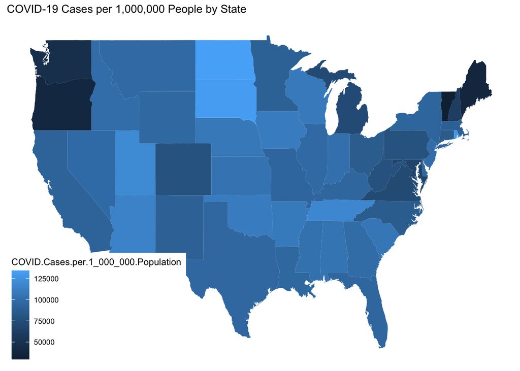

```r
casesStateMap <- highestCovidCasesStates %>%
  mutate("State Name" = tolower(`Location`)) %>%
  right_join(state, by = c("State Name" = "region"))

ggplot(casesStateMap, aes(x=long, y = lat, fill=COVID.Cases.per.1_000_000.Population)) + geom_polygon(aes(group=group)) + theme_map() + ggtitle("COVID-19 Cases per 1,000,000 People by State")
```

```r
highestCovidDeathsStates <- raw_data2
highestCovidDeathsStates$COVID.Deaths.per.1_000_000.Population <- as.numeric(highestCovidDeathsStates$COVID.Deaths.per.1_000_000.Population)
highestCovidDeathsStates <- highestCovidDeathsStates[order(highestCovidDeathsStates$COVID.Deaths.per.1_000_000.Population,decreasing = TRUE),]
highestCovidDeathsStates <- highestCovidDeathsStates %>% filter(COVID.Deaths.per.1_000_000.Population != 'N/A') %>%
  select(Location,COVID.Deaths.per.1_000_000.Population)
highestCovidDeathsStates
```

```
## # A tibble: 53 x 2
##    Location      COVID.Deaths.per.1_000_000.Population
##    <chr>                                         <dbl>
##  1 New Jersey                                     2742
##  2 New York                                       2562
##  3 Massachusetts                                  2474
##  4 Rhode Island                                   2462
##  5 Mississippi                                    2351
##  6 Arizona                                        2322
##  7 Connecticut                                    2206
##  8 South Dakota                                   2179
##  9 Louisiana                                      2170
## 10 Alabama                                        2146
## # … with 43 more rows
```

```r
lowestCovidDeathsStates <- raw_data2
lowestCovidDeathsStates$COVID.Deaths.per.1_000_000.Population <- as.numeric(lowestCovidDeathsStates$COVID.Deaths.per.1_000_000.Population)
lowestCovidDeathsStates <- lowestCovidDeathsStates[order(lowestCovidDeathsStates$COVID.Deaths.per.1_000_000.Population),]
lowestCovidDeathsStates <- lowestCovidDeathsStates %>% filter(COVID.Deaths.per.1_000_000.Population != 'N/A') %>%
  select(Location,COVID.Deaths.per.1_000_000.Population)
lowestCovidDeathsStates
```

```
## # A tibble: 53 x 2
##    Location      COVID.Deaths.per.1_000_000.Population
##    <chr>                                         <dbl>
##  1 Hawaii                                          323
##  2 Vermont                                         359
##  3 Alaska                                          428
##  4 Maine                                           544
##  5 Oregon                                          562
##  6 Utah                                            652
##  7 Puerto Rico                                     659
##  8 Washington                                      685
##  9 New Hampshire                                   905
## 10 Colorado                                       1056
## # … with 43 more rows
```

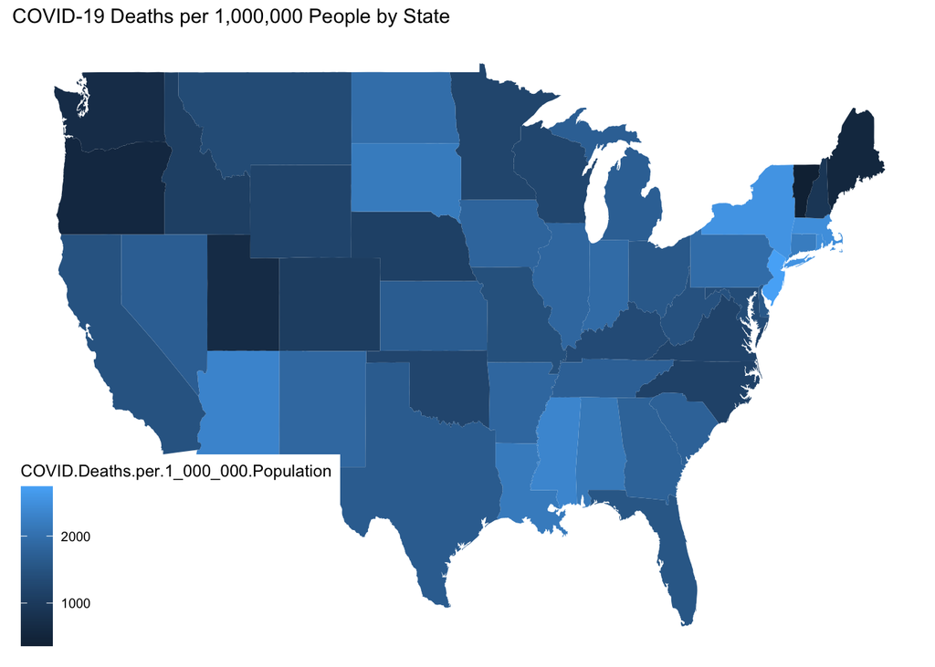

```r
deathsStateMap <- highestCovidDeathsStates %>%
  mutate("State Name" = tolower(`Location`)) %>%
  right_join(state, by = c("State Name" = "region"))

ggplot(deathsStateMap, aes(x=long, y = lat, fill=COVID.Deaths.per.1_000_000.Population)) + geom_polygon(aes(group=group)) + theme_map() + ggtitle("COVID-19 Deaths per 1,000,000 People by State")
```

**5. What patterns are shown when looking at a patient’s death (post vaccine) and the reasons why they might have died?**

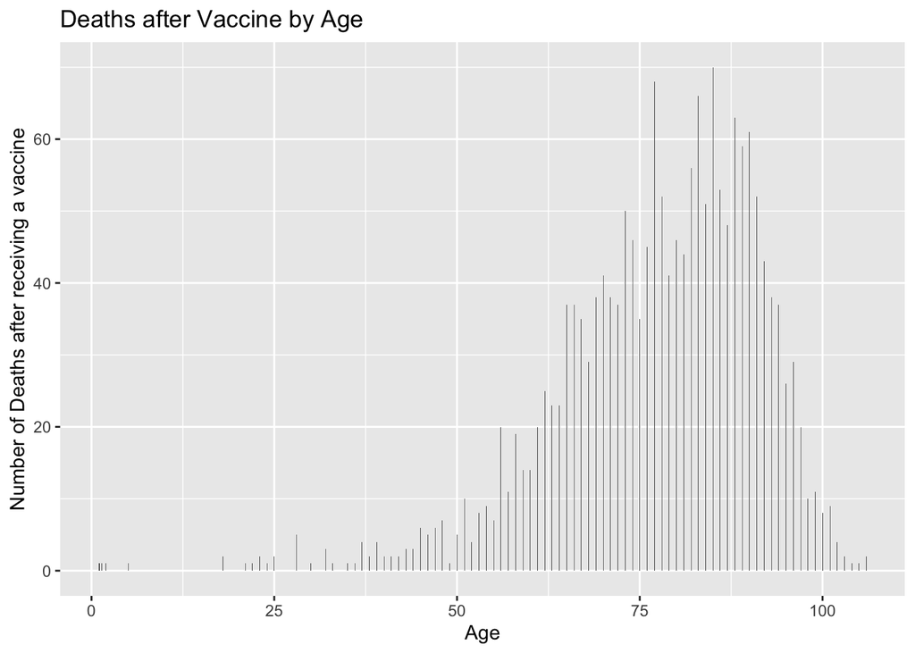

```r
#Age
deathAfterVax <- VAERSdata %>% filter(DIED=='Y')
deathAfterVaxAge <- deathAfterVax %>% count(AGE_YRS)
ggplot(deathAfterVaxAge,aes(x=AGE_YRS,y=n)) + geom_col() + ggtitle("Deaths after Vaccine by Age") + xlab("Age") + ylab("Number of Deaths after receiving a vaccine")
```

```r
#Gender
deathAfterVaxSex <- deathAfterVax %>% count(SEX) %>% filter(SEX !='U')
deathAfterVaxSex
```

```
## # A tibble: 2 x 2
##   SEX       n
##   <chr> <int>
## 1 F       849
## 2 M      1066
```

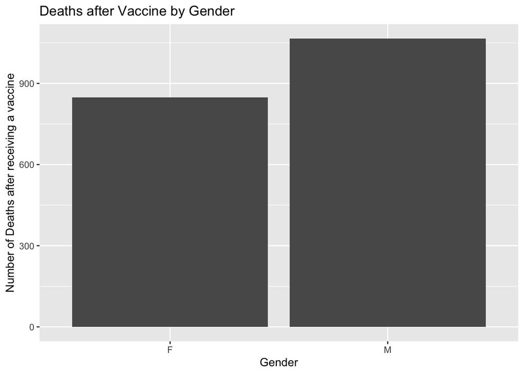

```r
ggplot(deathAfterVaxSex,aes(x=SEX,y=n)) + geom_col() + ggtitle("Deaths after Vaccine by Gender") + xlab("Gender") + ylab("Number of Deaths after receiving a vaccine")
```

```r
#Common symptoms after vax in deaths
deathSymptoms <- deathAfterVax %>% left_join(VAERSsymptoms, by = 'VAERS_ID') %>% group_by(VAERS_ID) %>%
  select(VAERS_ID, AGE_YRS, SEX, SYMPTOM1, SYMPTOM2, SYMPTOM3, SYMPTOM4, SYMPTOM5)

tail(names(sort(table(deathSymptoms$SYMPTOM1))), 5)
```

```
## [1] "Unresponsive to stimuli" "Asthenia"
## [3] "COVID-19"                "Cardiac arrest"
## [5] "Death"
```

```r
tail(names(sort(table(deathSymptoms$SYMPTOM2))), 5)
```

```
## [1] "Resuscitation"           "Unresponsive to stimuli"
## [3] "Cardiac arrest"          "Dyspnoea"
## [5] "Death"
```

```r
tail(names(sort(table(deathSymptoms$SYMPTOM3))), 5)
```

```
## [1] "Resuscitation"            "Unresponsive to stimuli"
## [3] "SARS-CoV-2 test positive" "Dyspnoea"
## [5] "Death"
```

```r
tail(names(sort(table(deathSymptoms$SYMPTOM4))), 5)
```

```
## [1] "Resuscitation"           "Pyrexia"
## [3] "Dyspnoea"                "Unresponsive to stimuli"
## [5] "Death"
```

```r
tail(names(sort(table(deathSymptoms$SYMPTOM5))), 5)
```

```
## [1] "Vomiting"                "Resuscitation"
## [3] "Dyspnoea"                "Unresponsive to stimuli"
## [5] "Death"
```

**6. What age group has gotten the most vaccines?**

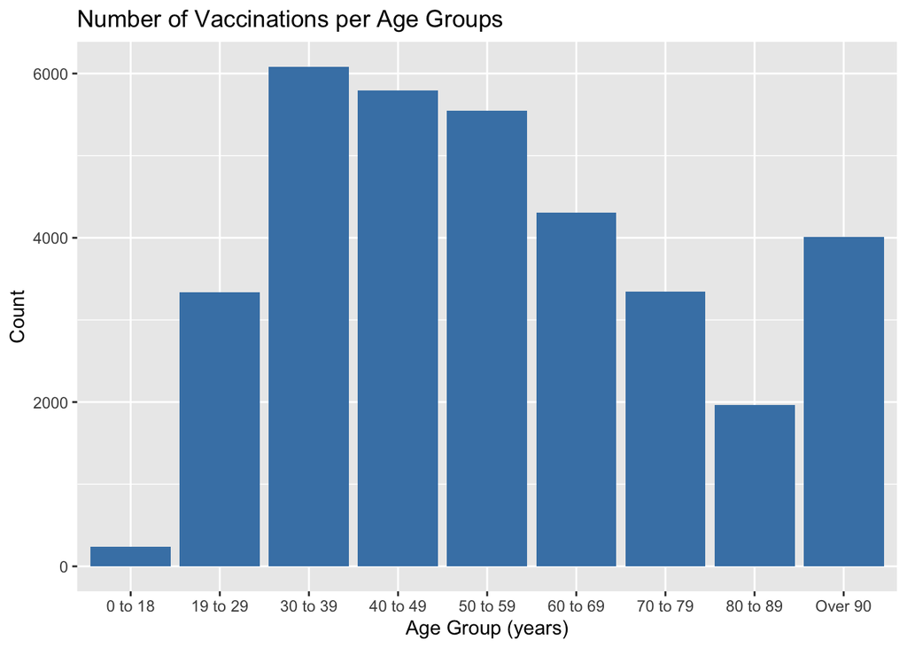

```r
# joining general patient data and vax data
age <- VAERSdata %>% full_join(VAERSVax, by = 'VAERS_ID') %>%
  select(VAERS_ID, VAX_MANU, AGE_YRS)
# adding 10 year age group column to sort ages
age <- age %>%
  mutate(AGE_GROUP = ifelse(AGE_YRS %in% 0:18, '0 to 18',
                     ifelse(AGE_YRS %in% 19:29, '19 to 29',
                     ifelse(AGE_YRS %in% 30:39, '30 to 39',
                     ifelse(AGE_YRS %in% 40:49, '40 to 49',
                     ifelse(AGE_YRS %in% 50:59, '50 to 59',
                     ifelse(AGE_YRS %in% 60:69, '60 to 69',
                     ifelse(AGE_YRS %in% 70:79, '70 to 79',
                     ifelse(AGE_YRS %in% 80:89, '80 to 89', 'Over 90')))))))))
# plotting visual representation
ggplot(age, aes(x = AGE_GROUP)) + geom_bar(fill = 'steelblue') +
  ggtitle('Number of Vaccinations per Age Groups') +
  xlab('Age Group (years)') + ylab('Count')
```

```r
# numerical stats
table(age$AGE_GROUP)
```

```
##
##  0 to 18 19 to 29 30 to 39 40 to 49 50 to 59 60 to 69 70 to 79 80 to 89
##      242     3333     6083     5790     5551     4307     3347     1963
##  Over 90
##     4014
```

**7. What is the most popular vaccine manufacturer per state?**

```r
# Joining vaccine dataset with 'data' dataset, only need state, ID number, and vaccine manufacturer
#Summarizing such that the number of each type of vaccine will be counted in each state
perState <- VAERSVax %>% full_join(VAERSdata) %>%
  select(VAERS_ID, STATE, VAX_MANU) %>%
  group_by(STATE, VAX_MANU) %>%
  summarise(popular = n())
#Selecting the top vaccine distributor for each state
topPerState <- top_n(perState, 1) %>%
  select(-popular)
topPerState <- na.omit(topPerState) %>%
  filter(STATE %notin% c('AS', 'Ca', 'FM', 'GU', 'MH', 'MP', 'PR', 'VI', 'XB'))
head(topPerState, 10)
```

```
## # A tibble: 10 x 2
## # Groups:   STATE [10]
##    STATE VAX_MANU
##    <chr> <chr>
##  1 AK    "PFIZER\\BIONTECH"
##  2 AL    "PFIZER\\BIONTECH"
##  3 AR    "PFIZER\\BIONTECH"
##  4 AZ    "PFIZER\\BIONTECH"
##  5 CA    "PFIZER\\BIONTECH"
##  6 CO    "MODERNA"
##  7 CT    "MODERNA"
##  8 DC    "MODERNA"
##  9 DE    "PFIZER\\BIONTECH"
## 10 FL    "MODERNA"
```

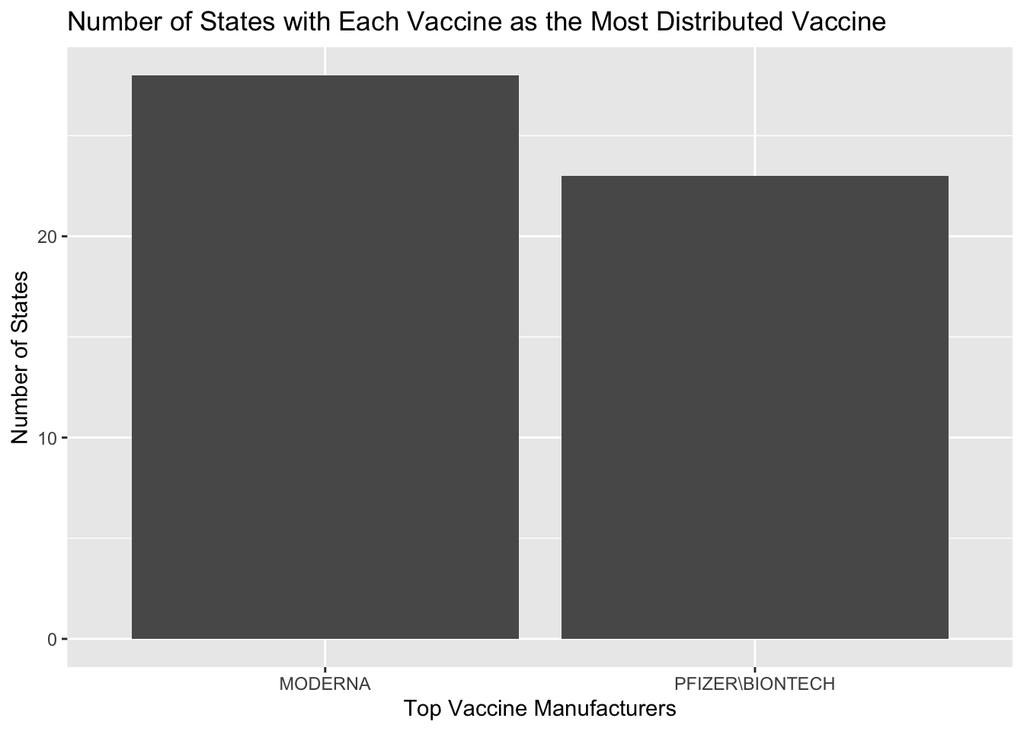

```r
#Visualizing what manufacturers are the most distributed in different states
ggplot(topPerState, aes(x = VAX_MANU)) + geom_bar() + xlab("Top Vaccine Manufacturers") + ylab("Number of States") + ggtitle("Number of States with Each Vaccine as the Most Distributed Vaccine")
```

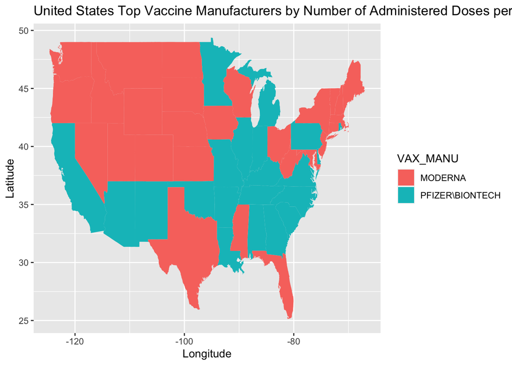

```r
#Creating a Map visualization of which states have each vaccine as the top manufacturer based on number administered
abbrev$State <- toupper(abbrev$State)

state1 <- state %>%
  select(long, lat, region, group)

state1$region <- toupper(state1$region)

stAbbrev <- state1 %>% right_join(abbrev, by = c('region' = 'State'))
stAbbrev <- stAbbrev %>%
  select(-Abbrev)

stAbbrevManu <- stAbbrev %>% right_join(topPerState, by = c('Code' = 'STATE'))

stAbbrevManu <- stAbbrevManu %>%
  mutate(VAX_MANU = as.factor(VAX_MANU))

ggplot(stAbbrevManu, aes(x = long, y = lat)) + geom_polygon(aes(group = group, fill = VAX_MANU)) + xlab("Longitude") + ylab("Latitude") + ggtitle("United States Top Vaccine Manufacturers by Number of Administered Doses per State")
```